```python
import pandas as pd
import matplotlib.pyplot as plt
```

# Step 1: Understand the problem and data

```python
# Reading & Examining the dataset
df = pd.read_excel("GDAC2M1A01_Project_ Assessing synthetic data scenarios dataset.xlsx")
```

```python
df.shape
```

```
(20, 4)
```

```python
df.head()
```

|  | heart_rate | blood_pressure | oxygen_saturation | health_status |
| --- | --- | --- | --- | --- |
| 0 | 104 | 126/80 | 95 | Stable |
| 1 | 68 | 118/78 | 92 | Deteriorating |
| 2 | 83 | 133/97 | 99 | Stable |
| 3 | 71 | 106/63 | 95 | Deteriorating |
| 4 | 86 | 131/89 | 98 | Stable |

```python
df.tail()
```

|  | heart_rate | blood_pressure | oxygen_saturation | health_status |
| --- | --- | --- | --- | --- |
| 15 | 73 | 137/76 | 93 | Stable |
| 16 | 61 | 114/99 | 97 | Stable |
| 17 | 107 | 134/61 | 97 | Stable |
| 18 | 67 | 92/82 | 94 | Deteriorating |
| 19 | 97 | 103/69 | 93 | Stable |

# Step 2: Analyze the real dataset

Enter the following prompt into Copilot online:

My data is stored in a dataframe called df with the following columns: heart_rate, blood_pressure, oxygen_saturation, and health_status.

Write Python code to perform the following tasks:

- Generate summary statistics (mean, median, range, etc.) for the numerical features: heart_rate and oxygen_saturation.
- Check for missing values across the entire dataframe.
- Visualize the data using histograms and scatter plots to understand the distributions of features and the relationships between them.

### Copy and paste the code provided by Copilot online:

```python
# Generate summary statistics
numerical_features = ['heart_rate', 'oxygen_saturation']
summary_stats = df[numerical_features].describe().T
summary_stats['range'] = summary_stats['max'] - summary_stats['min']
summary_stats = summary_stats[['mean', '50%', 'min', 'max', 'range']].rename(columns={'50%': 'median'})
print("Summary Statistics:")
print(summary_stats)
```

```
Summary Statistics:
                    mean  median   min    max  range
heart_rate         89.65    91.5  61.0  117.0   56.0
oxygen_saturation  95.15    95.0  92.0   99.0    7.0
```

```python
# Check for missing values
missing_values = df.isnull().sum()
print("\nMissing Values:")
print(missing_values)
```

```
Missing Values:
heart_rate           0
blood_pressure       0
oxygen_saturation    0
health_status        0
dtype: int64
```

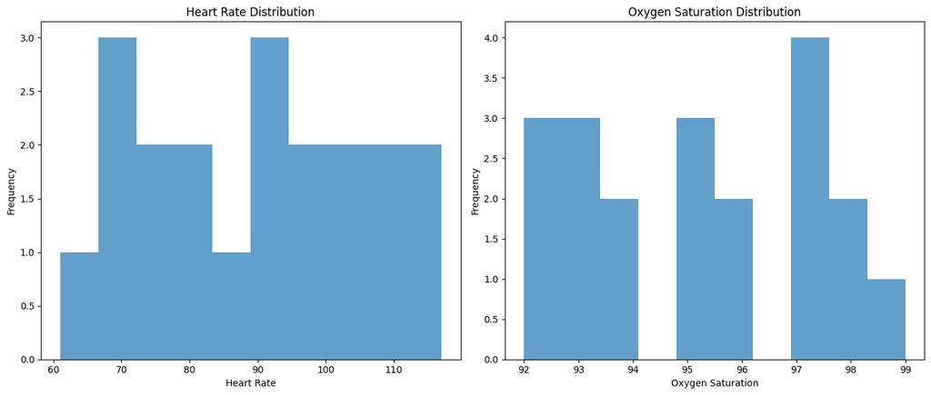

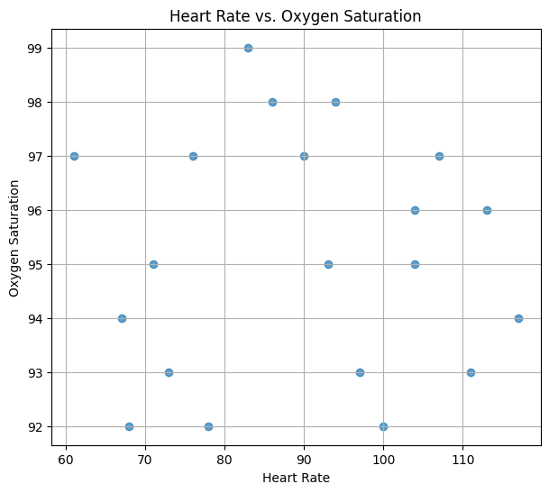

```python
# Visualize the data
plt.figure(figsize=(14, 6))

# Histograms
plt.subplot(1, 2, 1)
plt.hist(df['heart_rate'].dropna(), bins=10, alpha=0.7)
plt.title('Heart Rate Distribution')
plt.xlabel('Heart Rate')
plt.ylabel('Frequency')

plt.subplot(1, 2, 2)
plt.hist(df['oxygen_saturation'].dropna(), bins=10, alpha=0.7)
plt.title('Oxygen Saturation Distribution')
plt.xlabel('Oxygen Saturation')
plt.ylabel('Frequency')

plt.tight_layout()
plt.show()

# Scatter plot
plt.figure(figsize=(7, 6))
plt.scatter(df['heart_rate'], df['oxygen_saturation'], alpha=0.7)
plt.title('Heart Rate vs. Oxygen Saturation')
plt.xlabel('Heart Rate')
plt.ylabel('Oxygen Saturation')
plt.grid(True)
plt.show()
```

```python
# Is the dataset imbalanced?

df["health_status"].value_counts()
```

```
health_status
Stable           13
Deteriorating     7
Name: count, dtype: int64
```

```python
df["health_status"].value_counts(normalize=True)
```

```
health_status
Stable           0.65
Deteriorating    0.35
Name: proportion, dtype: float64
```

### 65% of the data is "Stable", 35% is "Deteriorating". The dataset is imbalanced in favor of stable cases.

### Privacy concerns: The dataset does not contain any sensitive patient information, and no individuals can be identified through its analysis.

# Step 3: Generate synthetic data

### Clean and preprocess the dataset:

```python
# Creating new columns for high and low blood pressure
df[['high_blood_pressure', 'low_blood_pressure']] = df['blood_pressure'].str.split('/', expand=True)
df['high_blood_pressure'] = df['high_blood_pressure'].astype(int)
df['low_blood_pressure'] = df['low_blood_pressure'].astype(int)

# Removing "blood_pressure" column
df.drop(columns=["blood_pressure"], inplace=True)
```

```python
# Creating binary labels to train the model
df['health_status'] = df['health_status'].map({'Stable': 0, 'Deteriorating': 1})
df['health_status'] = df['health_status'].astype(int)
```

```python
df.dtypes
```

```
heart_rate             int64
oxygen_saturation      int64
health_status          int64
high_blood_pressure    int64
low_blood_pressure     int64
dtype: object
```

```python
df.head()
```

|  | heart_rate | oxygen_saturation | health_status | high_blood_pressure | low_blood_pressure |
| --- | --- | --- | --- | --- | --- |
| 0 | 104 | 95 | 0 | 126 | 80 |
| 1 | 68 | 92 | 1 | 118 | 78 |
| 2 | 83 | 99 | 0 | 133 | 97 |
| 3 | 71 | 95 | 1 | 106 | 63 |
| 4 | 86 | 98 | 0 | 131 | 89 |

### There are no missing values in the DataFrame, so the data cleaning and preprocessing are complete.

### Training a logistic regression model on a real dataset:

```python
from sklearn.model_selection import train_test_split
from sklearn.linear_model import LogisticRegression
```

```python
# Prepare features and target variable
X = df[['heart_rate', 'high_blood_pressure', 'low_blood_pressure', 'oxygen_saturation']]
y = df['health_status']
# Train-test split
X_train, X_test, y_train, y_test = train_test_split(X, y, test_size=0.2, random_state=42)
# Train the model
model = LogisticRegression()
model.fit(X_train, y_train)
```

```
LogisticRegression()
```

### Evaluating the model's performance:

```python
from sklearn.metrics import accuracy_score, confusion_matrix, classification_report, roc_auc_score
```

```python
# Predicting on the test set
y_pred = model.predict(X_test)
y_pred_proba = model.predict_proba(X_test)[:, 1]

# Accuracy
accuracy = accuracy_score(y_test, y_pred)
print(f"Accuracy: {accuracy}")

# Confusion Matrix
conf_matrix = confusion_matrix(y_test, y_pred)
print(f"Confusion Matrix:\n{conf_matrix}")

# Classification Report (Precision, Recall, F1-Score)
class_report = classification_report(y_test, y_pred)
print(f"Classification Report:\n{class_report}")

# ROC AUC Score
roc_auc = roc_auc_score(y_test, y_pred_proba)
print(f"ROC AUC Score: {roc_auc}")
```

```
Accuracy: 0.75
Confusion Matrix:
[[2 1]
 [0 1]]
Classification Report:
              precision    recall  f1-score   support

           0       1.00      0.67      0.80         3
           1       0.50      1.00      0.67         1

    accuracy                           0.75         4
   macro avg       0.75      0.83      0.73         4
weighted avg       0.88      0.75      0.77         4

ROC AUC Score: 1.0
```

### Enter the following prompt into Copilot online to generate synthetic data:

This is my dataframe:

heart_rate oxygen_saturation health_status high_blood_pressure low_blood_pressure

0 104 95 0 126 80

1 68 92 1 118 78

2 83 99 0 133 97

3 71 95 1 106 63

4 86 98 0 131 89

5 76 97 0 141 65

6 111 93 1 147 72

7 100 92 1 93 96

8 90 97 0 145 96

9 104 96 0 101 85

10 78 92 1 123 61

11 93 95 0 109 79

12 117 94 0 136 60

13 94 98 0 112 85

14 113 96 1 128 69

15 73 93 0 137 76

16 61 97 0 114 99

17 107 97 0 134 61

18 67 94 1 92 82

19 97 93 0 103 69

Generate a new balanced dataset similar to the provided DataFrame. The new dataset should maintain the same structure, column names, and data types as the original. Ensure class distributions are balanced for categorical features, and preserve realistic ranges, distributions, and relationships for numerical features. Output the data values in a format ready for use as a pandas DataFrame, including an additional column indicating whether each row is from real or generated data.

### Copy and paste the code provided by Copilot online:

```python
from imblearn.over_sampling import SMOTE
```

```python
# Add a column indicating if the data is real or generated
df['source'] = 'real'

# Defining the number of samples
total_samples = 100

# Separate features and target
X = df[['heart_rate', 'oxygen_saturation', 'high_blood_pressure', 'low_blood_pressure']]
y = df['health_status']

# Apply SMOTE to balance the dataset
smote = SMOTE(random_state=42)
X_resampled, y_resampled = smote.fit_resample(X, y)

# Generate additional samples to create 100 rows
while len(X_resampled) < total_samples:
    X_additional, y_additional = smote.fit_resample(X, y)
    X_resampled = pd.concat([pd.DataFrame(X_resampled), pd.DataFrame(X_additional)], ignore_index=True)
    y_resampled = pd.concat([pd.Series(y_resampled), pd.Series(y_additional)], ignore_index=True)
    # Trim the excess rows if necessary
    if len(X_resampled) > total_samples:
        X_resampled = X_resampled[:total_samples]
        y_resampled = y_resampled[:total_samples]

# Create a new balanced DataFrame with 100 rows
balanced_df = pd.DataFrame(X_resampled, columns=['heart_rate', 'oxygen_saturation', 'high_blood_pressure', 'low_blood_pressure'])
balanced_df['health_status'] = y_resampled
balanced_df['source'] = 'generated'

# Concatenate the original and new DataFrames
combined_df = pd.concat([df, balanced_df], ignore_index=True)

print("Combined DataFrame:")
print(combined_df.shape)
print(combined_df.head())
```

```
Combined DataFrame:
(120, 6)
   heart_rate  oxygen_saturation  health_status  high_blood_pressure  \
0         104                 95              0                  126
1          68                 92              1                  118
2          83                 99              0                  133
3          71                 95              1                  106
4          86                 98              0                  131

   low_blood_pressure source
0                  80   real
1                  78   real
2                  97   real
3                  63   real
4                  89   real
```

```python
combined_df['health_status'].value_counts(normalize=True)
```

```
health_status
0    0.541667
1    0.458333
Name: proportion, dtype: float64
```

# Step 4: Evaluate synthetic data

```python
# Separate real and generated data
real_data = combined_df[combined_df["source"] == "real"]
generated_data = combined_df[combined_df["source"] == "generated"]
```

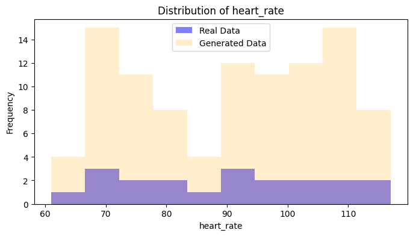

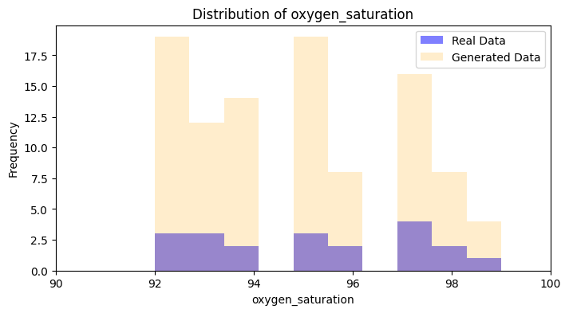

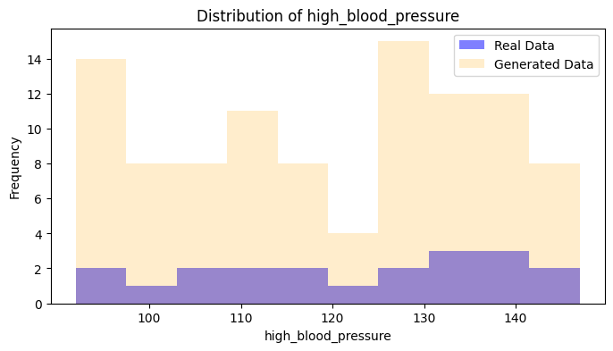

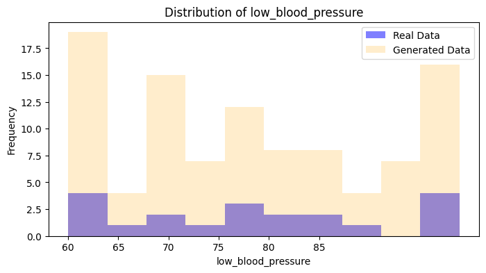

```python
# Visualization: Histograms for numerical features
numerical_columns = ["heart_rate", "oxygen_saturation", "high_blood_pressure", "low_blood_pressure"]

# Define tick intervals for specific columns if needed
tick_intervals = {
    "heart_rate": range(60, 120, 10),
    "oxygen_saturation": range(90, 101, 2),
    "high_blood_pressure": range(100, 150, 10),
    "low_blood_pressure": range(60, 90, 5),
}

for col in numerical_columns:
    plt.figure(figsize=(8, 4))
    plt.hist(real_data[col], bins=10, alpha=0.5, label="Real Data", color="blue")
    plt.hist(generated_data[col], bins=10, alpha=0.2, label="Generated Data", color="orange")
    plt.title(f"Distribution of {col}")
    plt.xlabel(col)
    plt.ylabel("Frequency")
    plt.legend()

    # Apply custom xticks if defined for the column
    if col in tick_intervals:
        plt.xticks(tick_intervals[col])

    plt.show()
```

The **Kolmogorov-Smirnov (KS)** test is a non-parametric test used to compare the distributions of two datasets.

The KS test compares the entire distribution, considering differences in shape, central tendency, and variability. This makes it a better choice when we want to evaluate whether two datasets are drawn from the same underlying distribution, regardless of their form.

In the **KS** test, the null hypothesis is:

"The two datasets come from the same distribution."

This means that if the null hypothesis is true, there should be no significant differences in the shapes, central tendencies, or variability of the two distributions being compared.

If the test returns a low p-value (typically below 0.05), you reject the null hypothesis, concluding that the two datasets are not drawn from the same distribution.

If the p-value is high, you fail to reject the null hypothesis, meaning there is no strong evidence to suggest that the distributions are different. They could be from the same distribution.

```python
from scipy.stats import ks_2samp

# Statistical Analysis: Kolmogorov-Smirnov Test
print("KS Test for Numerical Features")
alpha = 0.05  # Significance level

for col in numerical_columns:
    ks_stat, p_value = ks_2samp(real_data[col], generated_data[col])
    conclusion = (
        "Reject the null hypothesis (distributions are significantly different)"
        if p_value < alpha
        else "Fail to reject the null hypothesis (no significant difference in distributions)"
    )
    print(f"{col}: KS statistic = {ks_stat:.2f}, p-value = {p_value:.2f} - {conclusion}")
```

```
KS Test for Numerical Features
heart_rate: KS statistic = 0.07, p-value = 1.00 - Fail to reject the null hypothesis (no significant difference in distributions)
oxygen_saturation: KS statistic = 0.09, p-value = 1.00 - Fail to reject the null hypothesis (no significant difference in distributions)
high_blood_pressure: KS statistic = 0.09, p-value = 1.00 - Fail to reject the null hypothesis (no significant difference in distributions)
low_blood_pressure: KS statistic = 0.05, p-value = 1.00 - Fail to reject the null hypothesis (no significant difference in distributions)
```